# TE2021

`` r partimat(formula = target ~ ds.lda.train$`1` + ds.lda.train$`2` + ds.lda.train$`3` + ds.lda.train$`4` , data=ds.lda.train, method = "lda", prec = 200) ``

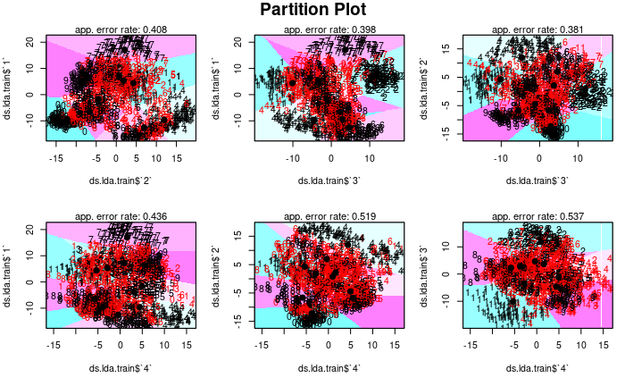

`` r partimat(formula = target ~ ds.qda.train$`1` + ds.qda.train$`2` + ds.qda.train$`3` + ds.qda.train$`4` , data=ds.qda.train, method = "qda", prec = 200, nplots.vert = 1 , nplots.hor = 1 ) ``

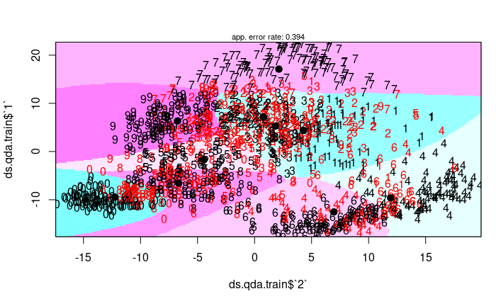

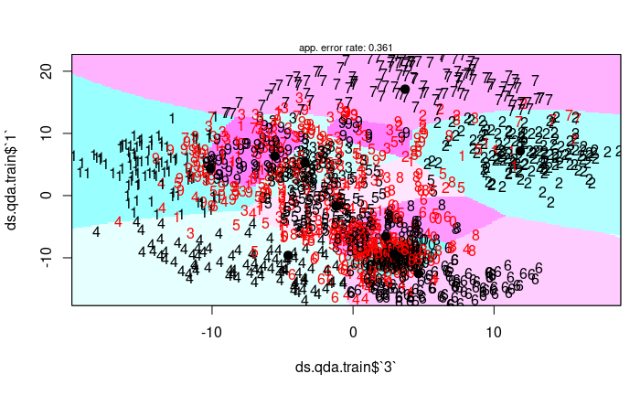

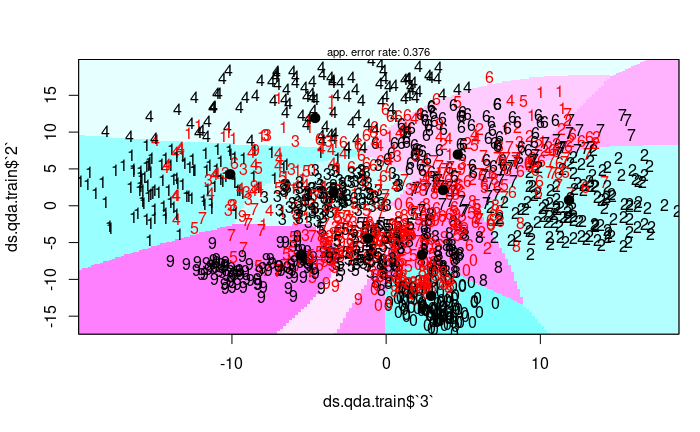

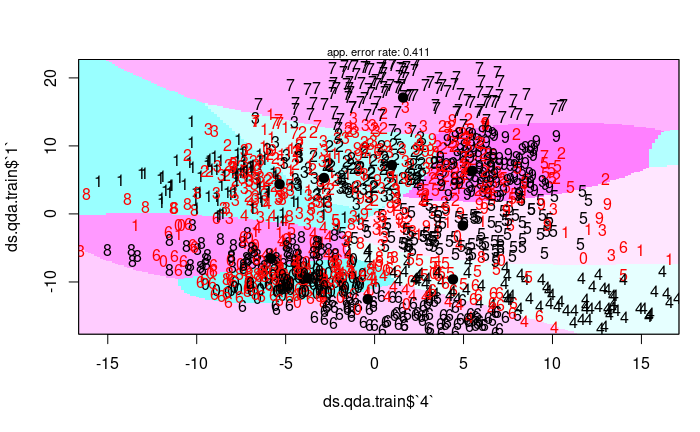

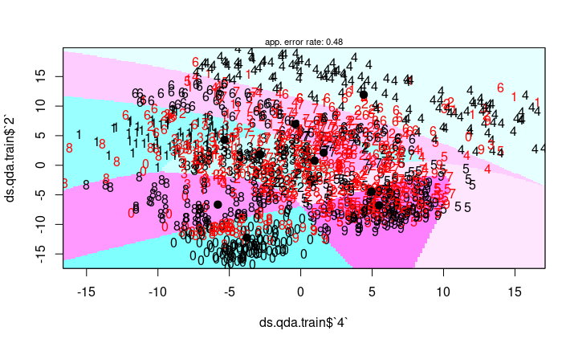

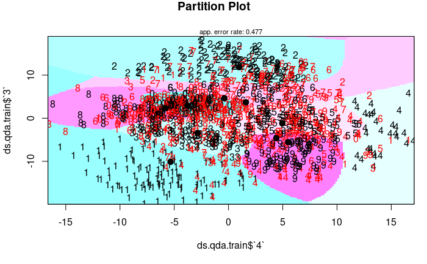

```r
ds.train.pca =  as.data.frame(as.matrix(ds.train[,1:640])%*%res.pca$rotation)
ds.test.pca =  as.data.frame(as.matrix(ds.test[,1:640])%*%res.pca$rotation)


pred_train = predict(model_tree_pca, ds.train.pca, type="class")
pred_test = predict(model_tree_pca, ds.test.pca, type="class")
#error de clasificación
mean(ifelse(ds.train.n$class==pred_train,1,0))
mean(ifelse(ds.test.n$class==pred_test,1,0))
```

[output not shown]

```r
apply(X = ds.train[,1:10], MARGIN = 2, FUN = mean)
```

```r
library(FactoMineR)
```

```r
res.pca2 <- PCA(X = ds.train.x[,1:10], scale.unit = FALSE, ncp = 4, graph = TRUE)
```

```r
((as.matrix(ds.train.x[,1:10])-res.pca2$call$centre) %*% (res.pca2$var$coord))[1:10,]
```

```r
res.pca2$ind$cos2[1,]
```

```r
library(glmnet)
```

```r
set.seed(110)

XX<-model.matrix(lm(class~.,data=ds.train))
Xtest<-model.matrix(lm(class~.,data=ds.test))

cv.lasso<-cv.glmnet(x=XX,y=ds.train$class,family="multinomial",alpha=1,nfolds=3,trace.it=1)
ajustelasso<-glmnet(x=XX,y=ds.train$class,family="multinomial",alpha=1,lambda=cv.lasso$lambda.1se, trace.it=1)
mean(predict(ajustelasso,newx=Xtest,type="class")==ds.test$class)
```

[output not shown]

```r
library(caret)
```

```r
car::vif(lm(fac[,3]~.,data=fac[1:55]))
```

```r
heatmap(cor(fac),  Rowv = NA, Colv = NA)
```

[output not shown]

```r
heatmap(cor(subset(ds.train, select=c(-class))),  Rowv = NA, Colv = NA)
```

[output not shown]